# Practical Machine Learning (Prediction Assessment)

Zhang Haoquan

Friday, March 20, 2015

The goal of this project is to predict the ‘classe’ variable.

## Download and Clean Data

```r
library('caret')
library('plyr')
library('rpart')
library('lubridate')
```

```r
# Importing the data
setInternet2(T)
if(!file.exists('./training.csv'))
  download.file('https://d396qusza40orc.cloudfront.net/predmachlearn/pml-training.csv','./training.csv',mode='wb')

# Cleaning up the data using the condition [na.strings=c('','NA','#DIV/0!')]
data <- read.csv('./training.csv',na.strings=c('','NA','#DIV/0!'))
```

## Seperate data into Training and Testing

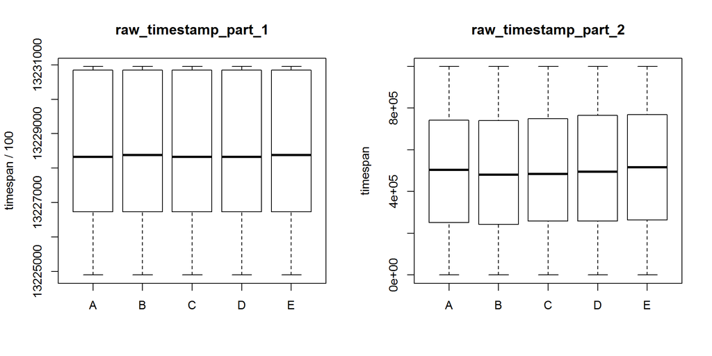

```r
inTrain  <- createDataPartition(y=data$classe, p=.7, list=FALSE)
training <- data[inTrain,]
testing  <- data[-inTrain,]

# Notice that raw_timestamp_part_1 and raw_timestamp_part_2 does not seem to appear as meaningful predictor
par(mfrow=c(1,2))
boxplot(data$raw_timestamp_part_1/100~data$classe,main='raw_timestamp_part_1',ylab='timespan / 100')
boxplot(data$raw_timestamp_part_2~data$classe,main='raw_timestamp_part_2', ylab='timespan')
```

## Reshape and Select Variables for Prediction

```r
prepData <- function(data){

  # Take away X, raw_timestamp_part_1, raw_timestamp_part_2
  data <- data[,-c(1,3,4)]

    # Reclassifying time to reflect qualitative properties such as weekday and hour of the day
    data$cvtd_timestamp <- strptime(as.character(data$cvtd_timestamp),'%d/%m/%Y %H:%M')
    data$cvtd_timestamp <- as.factor(paste(as.character(weekdays(data$cvtd_timestamp)),
                                               as.character(hour(data$cvtd_timestamp))))

    # Separate numeric Vs non-Numeric to perform selection
    numInd  <- !(names(data) %in% c('user_name','cvtd_timestamp','new_window','classe'))
    data_nonNum <- data[,(!numInd)]
    data_num    <- data[,(numInd)]

    # Removing columns with no variation
    data_num    <- data_num[,!is.na(apply(data_num,2,var))]

    # Scaling the remaining columns
    data_num <- as.data.frame(scale(data_num))

    # return the processed data
    cbind(data_num,data_nonNum)
}
```

## Train and Perform 10-Kold Validation

### Out-of-Sample Error

In the train function, trControl with method ‘cv’ and number 10 will perform the 10-Fold Validation. It will first break the training set into 10 non-overlapping equal size sample. Then, it will leave 1 of the samples out and train on the rest. lastly, it will validate the accuracy against the sample that was left out. This whole process will be repeated for all 10 samples and the mean of all 10 accuracy rates will give an estimate of the out-of-sample error.

### Tuning

In the train function, tuneGrid specifies a set a parameters to be tested against during the model fitting. For K-th Nearest Neighbour (KNN), the tuning parameter is k, the number of neightbours. For rpart2 it is the depth of the tree. This is necessary for models with tuning parameters.

### Model Selection

There can be many classification models that one can try but i selected 2 out of the many to report. Based on the out-of-sample error, it seems that the k-th nearest neighbour method is the best. Also, based on the tunning results, the best parameter for k is 1. With our results. we conclude that the final model is 1-th nearest neighbour with expected accuracy of approximately 98.8%.

```r
training <- prepData(training)

# Catalogue of methods : http://topepo.github.io/caret/bytag.html

modFit_trees <- train(training$classe~.,method='rpart2',data=training,
                 trControl=trainControl(method="cv", number=10), tuneGrid=expand.grid(.maxdepth = seq(1,30,2)))
modFit_knn   <- train(training$classe~.,method='knn',data=training,
                 trControl=trainControl(method="cv", number=10), tuneGrid=expand.grid(.k = seq(1,20,2)))

modFit_trees
```

```
## CART
##
## 13737 samples
##    56 predictor
##     5 classes: 'A', 'B', 'C', 'D', 'E'
##
## No pre-processing
## Resampling: Cross-Validated (10 fold)
##
## Summary of sample sizes: 12363, 12364, 12364, 12364, 12364, 12362, ...
##
## Resampling results across tuning parameters:
##
##   maxdepth  Accuracy   Kappa      Accuracy SD  Kappa SD
##    1        0.3661634  0.1245314  0.006244135  0.009200649
##    3        0.5681725  0.4462075  0.030605622  0.044207905
##    5        0.5746499  0.4566856  0.016438322  0.021180091
##    7        0.5980229  0.4874372  0.016589428  0.020335352
##    9        0.6726371  0.5848181  0.024819021  0.031050286
##   11        0.6789721  0.5928878  0.016595519  0.019819911
##   13        0.7178435  0.6422455  0.016396888  0.021815320
##   15        0.7437577  0.6760619  0.023644502  0.029973411
##   17        0.7569359  0.6928956  0.017154141  0.022320459
##   19        0.7771732  0.7186062  0.018567377  0.023643541
##   21        0.7939886  0.7396440  0.015320651  0.019950498
##   23        0.8078181  0.7569169  0.018641720  0.023989776
##   25        0.8209224  0.7732204  0.024435797  0.031318611
##   27        0.8229611  0.7757763  0.025721686  0.032968986
##   29        0.8229611  0.7757763  0.025721686  0.032968986
##
## Accuracy was used to select the optimal model using  the largest value.
## The final value used for the model was maxdepth = 27.
```

```r
modFit_knn
```

```
## k-Nearest Neighbors
##
## 13737 samples
##    56 predictor
##     5 classes: 'A', 'B', 'C', 'D', 'E'
##
## No pre-processing
## Resampling: Cross-Validated (10 fold)
##
## Summary of sample sizes: 12364, 12363, 12365, 12363, 12365, 12362, ...
##
## Resampling results across tuning parameters:
##
##   k   Accuracy   Kappa      Accuracy SD  Kappa SD
##    1  0.9876250  0.9843476  0.002298999  0.002907151
##    3  0.9740847  0.9672194  0.001650650  0.002090454
##    5  0.9626550  0.9527577  0.002837475  0.003587797
##    7  0.9498430  0.9365378  0.005563066  0.007041508
##    9  0.9392132  0.9230839  0.007773082  0.009845613
##   11  0.9282234  0.9091743  0.006862191  0.008675207
##   13  0.9207985  0.8997705  0.008601444  0.010907983
##   15  0.9122801  0.8889884  0.009650086  0.012234137
##   17  0.9033260  0.8776687  0.010888089  0.013798665
##   19  0.8961906  0.8686654  0.010276105  0.013016059
##
## Accuracy was used to select the optimal model using  the largest value.
## The final value used for the model was k = 1.
```

## Testing

Here we display the confusion matrix for our final model tested against the testing set. The accuracy yield is expected.

```r
testing  <- prepData(testing)
confusionMatrix(data=predict(modFit_knn,testing),testing$classe)
```

```
## Confusion Matrix and Statistics
##
##           Reference
## Prediction    A    B    C    D    E
##          A 1668    7    0    2    0
##          B    2 1124    5    0    2
##          C    2    6 1009   10    2
##          D    2    1   12  950    3
##          E    0    1    0    2 1075
##
## Overall Statistics
##
##                Accuracy : 0.99
##                  95% CI : (0.9871, 0.9924)
##     No Information Rate : 0.2845
##     P-Value [Acc > NIR] : < 2.2e-16
##
##                   Kappa : 0.9873
##  Mcnemar's Test P-Value : NA
##
## Statistics by Class:
##
##                      Class: A Class: B Class: C Class: D Class: E
## Sensitivity            0.9964   0.9868   0.9834   0.9855   0.9935
## Specificity            0.9979   0.9981   0.9959   0.9963   0.9994
## Pos Pred Value         0.9946   0.9921   0.9806   0.9814   0.9972
## Neg Pred Value         0.9986   0.9968   0.9965   0.9972   0.9985
## Prevalence             0.2845   0.1935   0.1743   0.1638   0.1839
## Detection Rate         0.2834   0.1910   0.1715   0.1614   0.1827
## Detection Prevalence   0.2850   0.1925   0.1749   0.1645   0.1832
## Balanced Accuracy      0.9971   0.9925   0.9897   0.9909   0.9965
```

## Prediction

This part of the code is used answer the 20 questions required for submission. They will not be printed for security reasons.

```r
# if(!file.exists('./testing.csv'))
#   download.file('https://d396qusza40orc.cloudfront.net/predmachlearn/pml-testing.csv','./testing.csv', mode='wb')
#
# pml_write_files = function(x){
#   n = length(x)
#   for(i in 1:n){
#     filename = paste0("problem_id_",i,".txt")
#     write.table(x[i],file=filename,quote=FALSE,row.names=FALSE,col.names=FALSE)
#   }
# }
# challenge <- prepData(read.csv('./testing.csv',na.strings=c('','NA','#DIV/0!')))
# pml_write_files(predict(modFit_knn,challenge))
```